# Telco Customer Churn Analysis

**v2 — Enhanced Edition**

**Dataset:** IBM Telco Customer Churn (~7,043 rows)  
**Goal:** Predict which customers will churn and quantify the business impact.

### What this notebook covers

| Section | Content |
| --- | --- |
| 1 | Setup & Data Loading |
| 2 | Data Cleaning & Quality |
| 3 | Exploratory Data Analysis (10 charts) |
| 4 | Feature Engineering |
| 5 | Modeling — LR, Random Forest, XGBoost with cross-validation |
| 6 | Threshold Optimization |
| 7 | SHAP Explainability |
| 8 | Model Comparison Table |
| 9 | QC Checks |
| 10 | Business Insights & Revenue Impact |

```python
import warnings
warnings.filterwarnings('ignore')

import os, urllib.request, uuid
import numpy as np
import pandas as pd
import matplotlib
import matplotlib.pyplot as plt
import matplotlib.ticker as mtick
import seaborn as sns
import shap
import xgboost as xgb

from sklearn.model_selection import train_test_split, StratifiedKFold, cross_validate
from sklearn.preprocessing import StandardScaler
from sklearn.linear_model import LogisticRegression
from sklearn.ensemble import RandomForestClassifier
from sklearn.metrics import (
    classification_report, ConfusionMatrixDisplay,
    roc_auc_score, roc_curve, precision_recall_curve, average_precision_score
)
from sklearn.pipeline import Pipeline
from sklearn.calibration import calibration_curve

sns.set_theme(style='whitegrid', palette='Set2')
plt.rcParams.update({'figure.dpi': 110, 'axes.titlesize': 13, 'figure.figsize': (8, 4)})
pd.set_option('display.max_columns', 50)
pd.set_option('display.float_format', '{:.4f}'.format)
SEED = 42
print('Libraries loaded  |  XGBoost', xgb.__version__, ' | SHAP', shap.__version__)
```

```
Libraries loaded  |  XGBoost 3.3.0  | SHAP 0.52.0
```

## 1. Data Loading

```python
DATA_FILE = 'WA_Fn-UseC_-Telco-Customer-Churn.csv'
MIRROR = ('https://raw.githubusercontent.com/IBM/telco-customer-churn-on-icp4d'
          '/master/data/Telco-Customer-Churn.csv')

if not os.path.exists(DATA_FILE):
    print('Downloading dataset...')
    urllib.request.urlretrieve(MIRROR, DATA_FILE)
else:
    print(f'Local file found: {DATA_FILE}')

df_raw = pd.read_csv(DATA_FILE)
print(f'Shape: {df_raw.shape}')
df_raw.head()
```

```
Local file found: WA_Fn-UseC_-Telco-Customer-Churn.csv
Shape: (7043, 21)
```

|  | customerID | gender | SeniorCitizen | Partner | Dependents | tenure | PhoneService | MultipleLines | InternetService | OnlineSecurity | OnlineBackup | DeviceProtection | TechSupport | StreamingTV | StreamingMovies | Contract | PaperlessBilling | PaymentMethod | MonthlyCharges | TotalCharges | Churn |
| --- | --- | --- | --- | --- | --- | --- | --- | --- | --- | --- | --- | --- | --- | --- | --- | --- | --- | --- | --- | --- | --- |
| 0 | 7590-VHVEG | Female | 0 | Yes | No | 1 | No | No phone service | DSL | No | Yes | No | No | No | No | Month-to-month | Yes | Electronic check | 29.8500 | 29.85 | No |
| 1 | 5575-GNVDE | Male | 0 | No | No | 34 | Yes | No | DSL | Yes | No | Yes | No | No | No | One year | No | Mailed check | 56.9500 | 1889.5 | No |
| 2 | 3668-QPYBK | Male | 0 | No | No | 2 | Yes | No | DSL | Yes | Yes | No | No | No | No | Month-to-month | Yes | Mailed check | 53.8500 | 108.15 | Yes |
| 3 | 7795-CFOCW | Male | 0 | No | No | 45 | No | No phone service | DSL | Yes | No | Yes | Yes | No | No | One year | No | Bank transfer (automatic) | 42.3000 | 1840.75 | No |
| 4 | 9237-HQITU | Female | 0 | No | No | 2 | Yes | No | Fiber optic | No | No | No | No | No | No | Month-to-month | Yes | Electronic check | 70.7000 | 151.65 | Yes |

## 2. Data Cleaning

Known issues:

- `TotalCharges` is `object` dtype — 11 rows contain whitespace (customers with `tenure=0`)
- `SeniorCitizen` stored as 0/1 integer instead of Yes/No
- Target `Churn` needs encoding to 0/1

```python
df = df_raw.copy()

# Fix TotalCharges whitespace
blank_mask = df['TotalCharges'].str.strip() == ''
print(f'Blank TotalCharges rows (tenure=0 customers): {blank_mask.sum()}')
df.loc[blank_mask, 'TotalCharges'] = '0.0'
df['TotalCharges'] = pd.to_numeric(df['TotalCharges'])

# Fix SeniorCitizen dtype
df['SeniorCitizen'] = df['SeniorCitizen'].map({0: 'No', 1: 'Yes'})

# Encode target
df['Churn_Flag'] = (df['Churn'] == 'Yes').astype(int)

# Duplicate check
print(f'Duplicate customerIDs: {df["customerID"].duplicated().sum()}')
print(f'Total nulls: {df.isnull().sum().sum()}')
print(f'Rows: {len(df):,}  |  Overall churn rate: {df["Churn_Flag"].mean():.1%}')

# Numeric summary
df[['tenure','MonthlyCharges','TotalCharges']].describe().round(2)
```

```
Blank TotalCharges rows (tenure=0 customers): 11
Duplicate customerIDs: 0
Total nulls: 0
Rows: 7,043  |  Overall churn rate: 26.5%
```

|  | tenure | MonthlyCharges | TotalCharges |
| --- | --- | --- | --- |
| count | 7043.0000 | 7043.0000 | 7043.0000 |
| mean | 32.3700 | 64.7600 | 2279.7300 |
| std | 24.5600 | 30.0900 | 2266.7900 |
| min | 0.0000 | 18.2500 | 0.0000 |
| 25% | 9.0000 | 35.5000 | 398.5500 |
| 50% | 29.0000 | 70.3500 | 1394.5500 |
| 75% | 55.0000 | 89.8500 | 3786.6000 |
| max | 72.0000 | 118.7500 | 8684.8000 |

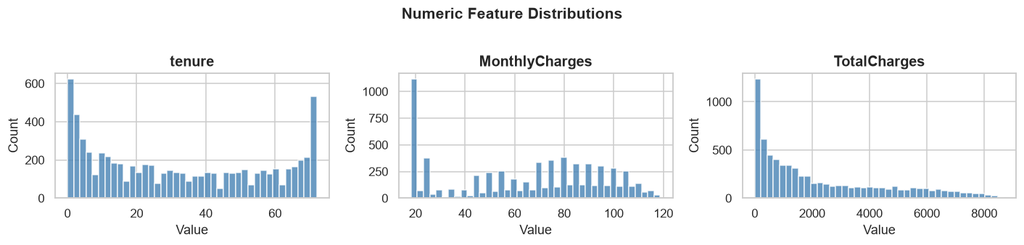

```
Saved: dist_numeric.png
```

```python
# Outlier check on numeric columns
fig, axes = plt.subplots(1, 3, figsize=(13, 3))
for ax, col in zip(axes, ['tenure', 'MonthlyCharges', 'TotalCharges']):
    ax.hist(df[col], bins=40, color='steelblue', edgecolor='white', alpha=0.8)
    ax.set_title(col, fontweight='bold')
    ax.set_xlabel('Value')
    ax.set_ylabel('Count')
plt.suptitle('Numeric Feature Distributions', fontsize=14, fontweight='bold', y=1.02)
plt.tight_layout()
plt.savefig('dist_numeric.png', bbox_inches='tight')
plt.show()
print('Saved: dist_numeric.png')
```

## 3. Exploratory Data Analysis

Ten charts covering demographics, contract structure, services, and spend patterns.

Helper function used throughout:

```python
AVG_CHURN = None   # set after df is ready

def churn_bar(ax, col, title, xlabel='', rotation=0, subset=None):
    """Bar chart of churn rate by column values."""
    data = df if subset is None else df[subset]
    rates = (data.groupby(col)['Churn_Flag']
                 .mean().sort_values(ascending=False).mul(100))
    palette = sns.color_palette('Set2', len(rates))
    bars = ax.bar(rates.index.astype(str), rates.values,
                  color=palette, edgecolor='white', linewidth=0.6)
    ax.yaxis.set_major_formatter(mtick.PercentFormatter())
    overall = data['Churn_Flag'].mean() * 100
    ax.axhline(overall, ls='--', color='tomato', lw=1.5, label=f'Avg {overall:.1f}%')
    ax.set_title(title, fontweight='bold', pad=8)
    ax.set_xlabel(xlabel or col)
    ax.set_ylabel('Churn Rate')
    ax.legend(fontsize=8)
    for bar in bars:
        ax.text(bar.get_x() + bar.get_width()/2, bar.get_height() + 0.5,
                f'{bar.get_height():.1f}%', ha='center', va='bottom', fontsize=8)
    if rotation:
        ax.tick_params(axis='x', rotation=rotation)
    return rates

print('Helper ready.')
```

```
Helper ready.
```

### 3.1 Churn by Contract Type

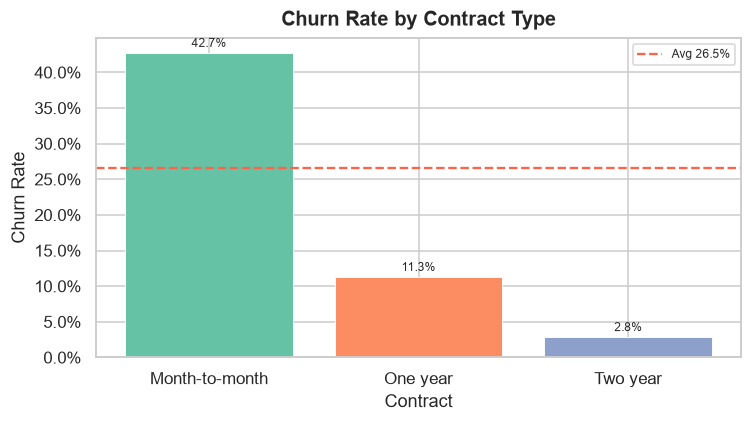

```
[INSIGHT] Month-to-month churns at 42.7% vs 2.8% for two-year -- 15x higher. Longer contracts are the #1 retention lever.
```

```python
fig, ax = plt.subplots(figsize=(7, 4))
r = churn_bar(ax, 'Contract', 'Churn Rate by Contract Type')
plt.tight_layout()
plt.savefig('eda_01_contract.png', bbox_inches='tight'); plt.show()
print(f'[INSIGHT] Month-to-month churns at {r.get("Month-to-month",0):.1f}% vs '
      f'{r.get("Two year",0):.1f}% for two-year -- {r.get("Month-to-month",0)/max(r.get("Two year",0.01),0.01):.0f}x higher.'
      ' Longer contracts are the #1 retention lever.')
```

### 3.2 Churn by Tenure Bucket

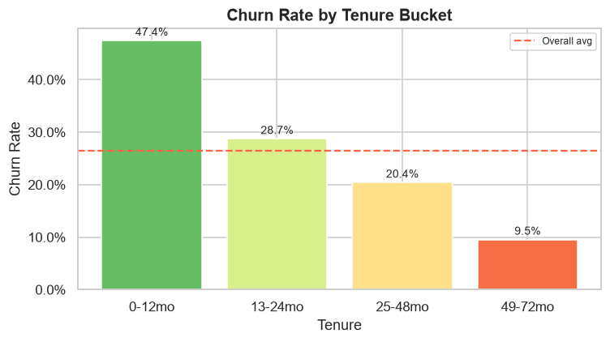

```
[INSIGHT] First-year customers churn at 47.4% vs 9.5% for 4+ year customers -- onboarding programmes target the highest-risk window.
```

```python
df['TenureBucket'] = pd.cut(df['tenure'],
    bins=[0,12,24,48,72], labels=['0-12mo','13-24mo','25-48mo','49-72mo'],
    include_lowest=True)

fig, ax = plt.subplots(figsize=(7, 4))
rt = (df.groupby('TenureBucket', observed=True)['Churn_Flag'].mean().mul(100))
colors = sns.color_palette('RdYlGn_r', 4)
bars = ax.bar(rt.index.astype(str), rt.values, color=colors, edgecolor='white')
ax.yaxis.set_major_formatter(mtick.PercentFormatter())
ax.axhline(df['Churn_Flag'].mean()*100, ls='--', color='tomato', lw=1.5, label='Overall avg')
ax.set_title('Churn Rate by Tenure Bucket', fontweight='bold')
ax.set_xlabel('Tenure'); ax.set_ylabel('Churn Rate'); ax.legend(fontsize=8)
for bar in bars:
    ax.text(bar.get_x()+bar.get_width()/2, bar.get_height()+0.5,
            f'{bar.get_height():.1f}%', ha='center', va='bottom', fontsize=9)
plt.tight_layout()
plt.savefig('eda_02_tenure.png', bbox_inches='tight'); plt.show()
print(f'[INSIGHT] First-year customers churn at {rt["0-12mo"]:.1f}% vs '
      f'{rt["49-72mo"]:.1f}% for 4+ year customers -- onboarding programmes '
      'target the highest-risk window.')
```

### 3.3 Churn by Internet Service Type

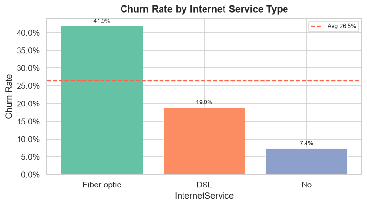

```
[INSIGHT] Fiber optic customers churn at 41.9% vs 19.0% for DSL. Despite faster speeds, fiber customers feel the price pain most acutely.
```

```python
fig, ax = plt.subplots(figsize=(7, 4))
ri = churn_bar(ax, 'InternetService', 'Churn Rate by Internet Service Type')
plt.tight_layout()
plt.savefig('eda_03_internet.png', bbox_inches='tight'); plt.show()
fo = ri.get('Fiber optic', 0)
dsl = ri.get('DSL', 0)
print(f'[INSIGHT] Fiber optic customers churn at {fo:.1f}% vs {dsl:.1f}% for DSL. '
      'Despite faster speeds, fiber customers feel the price pain most acutely.')
```

### 3.4 Churn by Payment Method

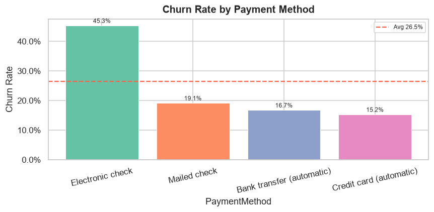

```
[INSIGHT] Electronic check payers churn at 45.3%. Auto-pay methods (credit card, bank transfer) correlate with lower churn -- payment friction signals low engagement.
```

```python
fig, ax = plt.subplots(figsize=(8, 4))
rpm = churn_bar(ax, 'PaymentMethod', 'Churn Rate by Payment Method', rotation=12)
plt.tight_layout()
plt.savefig('eda_04_payment.png', bbox_inches='tight'); plt.show()
top = rpm.idxmax()
print(f'[INSIGHT] {top} payers churn at {rpm[top]:.1f}%. '
      'Auto-pay methods (credit card, bank transfer) correlate with '
      'lower churn -- payment friction signals low engagement.')
```

### 3.5 Churn by Add-on Services

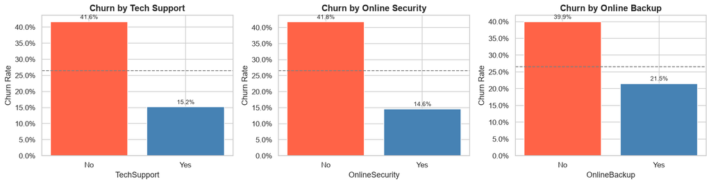

```
[INSIGHT] No tech support: 41.6% churn | With tech support: 15.2%. Add-ons create switching cost and perceived value -- bundle them proactively.
```

```python
fig, axes = plt.subplots(1, 3, figsize=(15, 4))
addons = [('TechSupport','Tech Support'),
          ('OnlineSecurity','Online Security'),
          ('OnlineBackup','Online Backup')]
for ax, (col, label) in zip(axes, addons):
    sub = df[df[col] != 'No internet service']
    rs = sub.groupby(col)['Churn_Flag'].mean().sort_values(ascending=False).mul(100)
    bars = ax.bar(rs.index, rs.values, color=['tomato','steelblue'], edgecolor='white')
    ax.yaxis.set_major_formatter(mtick.PercentFormatter())
    ax.axhline(df['Churn_Flag'].mean()*100, ls='--', color='grey', lw=1.2)
    ax.set_title(f'Churn by {label}', fontweight='bold')
    ax.set_xlabel(col); ax.set_ylabel('Churn Rate')
    for bar in bars:
        ax.text(bar.get_x()+bar.get_width()/2, bar.get_height()+0.5,
                f'{bar.get_height():.1f}%', ha='center', va='bottom', fontsize=9)
plt.tight_layout()
plt.savefig('eda_05_addons.png', bbox_inches='tight'); plt.show()
sub_ts = df[df['TechSupport']!='No internet service']
ts_no = sub_ts[sub_ts['TechSupport']=='No']['Churn_Flag'].mean()*100
ts_yes = sub_ts[sub_ts['TechSupport']=='Yes']['Churn_Flag'].mean()*100
print(f'[INSIGHT] No tech support: {ts_no:.1f}% churn | With tech support: {ts_yes:.1f}%. '
      'Add-ons create switching cost and perceived value -- bundle them proactively.')
```

### 3.6 Churn by Demographics

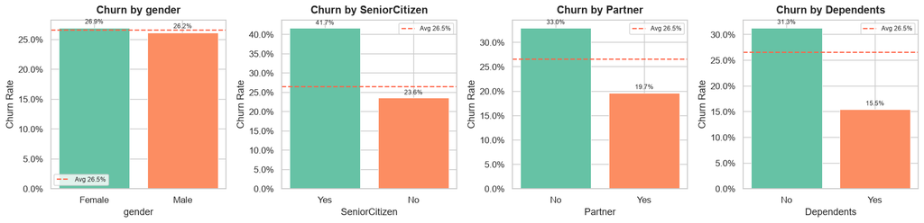

```
[INSIGHT] Senior citizens churn at 41.7% vs 23.6% for non-seniors. Customers without partners or dependents also churn more -- they have fewer reasons to stay on a family plan.
```

```python
fig, axes = plt.subplots(1, 4, figsize=(16, 4))
for ax, col in zip(axes, ['gender','SeniorCitizen','Partner','Dependents']):
    churn_bar(ax, col, f'Churn by {col}')
plt.tight_layout()
plt.savefig('eda_06_demographics.png', bbox_inches='tight'); plt.show()
sc_yes = df[df['SeniorCitizen']=='Yes']['Churn_Flag'].mean()*100
sc_no  = df[df['SeniorCitizen']=='No']['Churn_Flag'].mean()*100
print(f'[INSIGHT] Senior citizens churn at {sc_yes:.1f}% vs {sc_no:.1f}% for non-seniors. '
      'Customers without partners or dependents also churn more -- they have fewer '
      'reasons to stay on a family plan.')
```

### 3.7 Churn by Number of Active Services

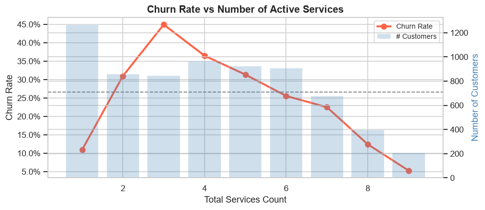

```
[INSIGHT] Customers with 1 service churn at 10.9% vs 5.3% for those with 9 services. Cross-selling reduces churn non-linearly.
```

```python
addon_cols = ['PhoneService','MultipleLines','InternetService',
              'OnlineSecurity','OnlineBackup','DeviceProtection',
              'TechSupport','StreamingTV','StreamingMovies']

def count_services(row):
    return sum(1 for c in addon_cols
               if str(row[c]).strip().lower()
               not in ('no','no phone service','no internet service','nan'))

df['TotalServicesCount'] = df.apply(count_services, axis=1)

fig, ax = plt.subplots(figsize=(9, 4))
rs = df.groupby('TotalServicesCount')['Churn_Flag'].mean().mul(100)
counts = df['TotalServicesCount'].value_counts().sort_index()
ax2 = ax.twinx()
ax2.bar(counts.index, counts.values, alpha=0.25, color='steelblue', label='# Customers')
ax2.set_ylabel('Number of Customers', color='steelblue')
ax.plot(rs.index, rs.values, 'o-', color='tomato', lw=2.5, ms=7, label='Churn Rate')
ax.yaxis.set_major_formatter(mtick.PercentFormatter())
ax.axhline(df['Churn_Flag'].mean()*100, ls='--', color='grey', lw=1.2)
ax.set_title('Churn Rate vs Number of Active Services', fontweight='bold')
ax.set_xlabel('Total Services Count')
ax.set_ylabel('Churn Rate')
lines1, labels1 = ax.get_legend_handles_labels()
lines2, labels2 = ax2.get_legend_handles_labels()
ax.legend(lines1+lines2, labels1+labels2, fontsize=9)
plt.tight_layout()
plt.savefig('eda_07_services_count.png', bbox_inches='tight'); plt.show()
low = rs.iloc[0]
high = rs.iloc[-1]
print(f'[INSIGHT] Customers with 1 service churn at {low:.1f}% vs {high:.1f}% '
      'for those with 9 services. Cross-selling reduces churn non-linearly.')
```

### 3.8 Churn Rate Heatmap — Contract × Tenure Bucket

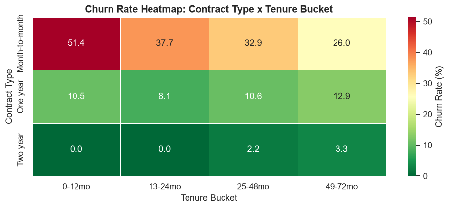

```
[INSIGHT] The top-left cell (Month-to-month + 0-12mo) is the single highest-risk segment. This is the primary target for early intervention programmes.
```

```python
pivot = (df.groupby(['Contract','TenureBucket'], observed=True)['Churn_Flag']
           .mean().mul(100).unstack())
fig, ax = plt.subplots(figsize=(9, 4))
sns.heatmap(pivot, annot=True, fmt='.1f', cmap='RdYlGn_r',
            linewidths=0.5, ax=ax, cbar_kws={'label': 'Churn Rate (%)'})
ax.set_title('Churn Rate Heatmap: Contract Type x Tenure Bucket', fontweight='bold')
ax.set_xlabel('Tenure Bucket'); ax.set_ylabel('Contract Type')
plt.tight_layout()
plt.savefig('eda_08_heatmap.png', bbox_inches='tight'); plt.show()
print('[INSIGHT] The top-left cell (Month-to-month + 0-12mo) is the '
      'single highest-risk segment. This is the primary target for '
      'early intervention programmes.')
```

### 3.9 Monthly Charges Distribution

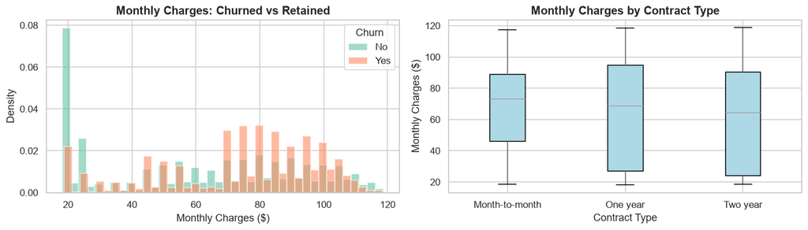

```
[INSIGHT] Churned avg spend: $74.44/mo vs $61.27/mo retained. High charges without perceived value drive churn -- pricing strategy must consider value-add.
```

```python
fig, axes = plt.subplots(1, 2, figsize=(13, 4))

# Left: churned vs retained
for label, grp in df.groupby('Churn'):
    axes[0].hist(grp['MonthlyCharges'], bins=40, alpha=0.6, density=True, label=label)
axes[0].set_title('Monthly Charges: Churned vs Retained', fontweight='bold')
axes[0].set_xlabel('Monthly Charges ($)'); axes[0].set_ylabel('Density')
axes[0].legend(title='Churn')

# Right: boxplot by contract type
df.boxplot(column='MonthlyCharges', by='Contract', ax=axes[1],
           patch_artist=True,
           boxprops=dict(facecolor='lightblue'))
axes[1].set_title('Monthly Charges by Contract Type', fontweight='bold')
axes[1].set_xlabel('Contract Type'); axes[1].set_ylabel('Monthly Charges ($)')
plt.suptitle('')
plt.tight_layout()
plt.savefig('eda_09_charges.png', bbox_inches='tight'); plt.show()
avg_c = df.groupby('Churn')['MonthlyCharges'].mean()
print(f'[INSIGHT] Churned avg spend: ${avg_c["Yes"]:.2f}/mo vs '
      f'${avg_c["No"]:.2f}/mo retained. High charges without perceived value '
      'drive churn -- pricing strategy must consider value-add.')
```

### 3.10 Feature Correlation Heatmap

Note: `TotalCharges` is highly correlated with `tenure × MonthlyCharges` — this is expected and will affect Logistic Regression coefficient interpretation.

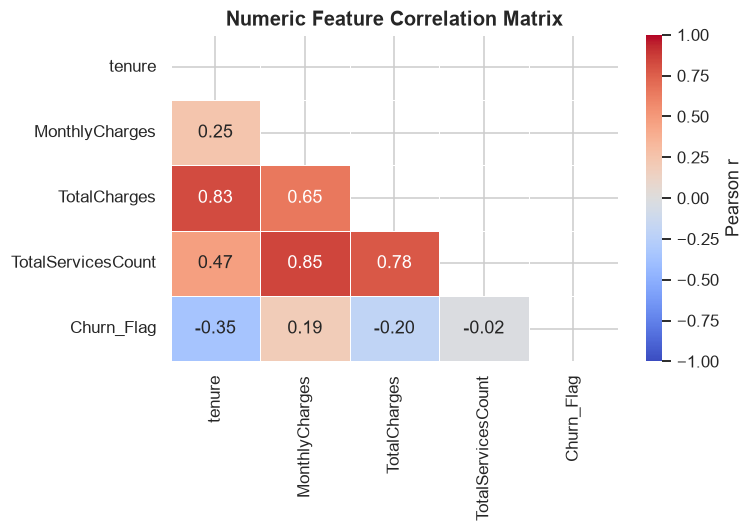

```
[NOTE] TotalCharges ~ tenure (r=0.83) and MonthlyCharges (r=0.65) -- near multicollinearity. LR coefficients should be interpreted with caution.
```

```python
num_cols = ['tenure','MonthlyCharges','TotalCharges',
            'TotalServicesCount','Churn_Flag']
corr = df[num_cols].corr()
mask = np.triu(np.ones_like(corr, dtype=bool))
fig, ax = plt.subplots(figsize=(7, 5))
sns.heatmap(corr, mask=mask, annot=True, fmt='.2f', cmap='coolwarm',
            vmin=-1, vmax=1, linewidths=0.5, ax=ax,
            cbar_kws={'label': 'Pearson r'})
ax.set_title('Numeric Feature Correlation Matrix', fontweight='bold')
plt.tight_layout()
plt.savefig('eda_10_correlation.png', bbox_inches='tight'); plt.show()
tc_tenure = corr.loc['TotalCharges','tenure']
tc_mc     = corr.loc['TotalCharges','MonthlyCharges']
print(f'[NOTE] TotalCharges ~ tenure (r={tc_tenure:.2f}) and '
      f'MonthlyCharges (r={tc_mc:.2f}) -- near multicollinearity. '
      'LR coefficients should be interpreted with caution.')
```

## 4. Feature Engineering

| Feature | Description |
| --- | --- |
| `TenureBucket_Ord` | Ordinal-encoded tenure range (0–3) |
| `TotalServicesCount` | Count of active add-on services (already created above) |
| `AvgSpendPerService` | `MonthlyCharges / (TotalServicesCount + 1)` |
| One-hot columns | `gender`, `InternetService`, `Contract`, `PaymentMethod` |

```python
# Avg spend per service
df['AvgSpendPerService'] = df['MonthlyCharges'] / (df['TotalServicesCount'] + 1)

# Tenure bucket ordinal
tenure_map = {'0-12mo':0,'13-24mo':1,'25-48mo':2,'49-72mo':3}
df['TenureBucket_Ord'] = df['TenureBucket'].map(tenure_map)

# Build model dataframe
drop_cols = ['customerID','Churn','TenureBucket']
df_model = df.drop(columns=drop_cols)

binary_map = {'Yes':1,'No':0,'No phone service':0,'No internet service':0}
binary_cols = ['Partner','Dependents','PhoneService','MultipleLines',
               'OnlineSecurity','OnlineBackup','DeviceProtection',
               'TechSupport','StreamingTV','StreamingMovies',
               'PaperlessBilling','SeniorCitizen']
for col in binary_cols:
    df_model[col] = df_model[col].map(binary_map)

ohe_cols = ['gender','InternetService','Contract','PaymentMethod']
df_model = pd.get_dummies(df_model, columns=ohe_cols, drop_first=True)

# Ensure all bool cols are int
bool_cols = df_model.select_dtypes(include='bool').columns
df_model[bool_cols] = df_model[bool_cols].astype(int)

print(f'Model matrix shape: {df_model.shape}')
print(f'Features ({len(df_model.columns)-1}):', [c for c in df_model.columns if c != 'Churn_Flag'])
```

```
Model matrix shape: (7043, 27)
Features (26): ['SeniorCitizen', 'Partner', 'Dependents', 'tenure', 'PhoneService', 'MultipleLines', 'OnlineSecurity', 'OnlineBackup', 'DeviceProtection', 'TechSupport', 'StreamingTV', 'StreamingMovies', 'PaperlessBilling', 'MonthlyCharges', 'TotalCharges', 'TotalServicesCount', 'AvgSpendPerService'…
```

### 4.1 Train / Test Split

```python
TARGET = 'Churn_Flag'
X = df_model.drop(columns=[TARGET])
y = df_model[TARGET]
FEATURE_NAMES = X.columns.tolist()

X_train, X_test, y_train, y_test = train_test_split(
    X, y, test_size=0.2, random_state=SEED, stratify=y)

print(f'Train: {len(X_train):,} rows  |  Test: {len(X_test):,} rows')
print(f'Train churn rate: {y_train.mean():.3f}  |  Test churn rate: {y_test.mean():.3f}')
```

```
Train: 5,634 rows  |  Test: 1,409 rows
Train churn rate: 0.265  |  Test churn rate: 0.265
```

## 5. Modeling

Three models trained with **5-fold stratified cross-validation** and `class_weight='balanced'`:

- **Logistic Regression** — interpretable coefficients, linear baseline
- **Random Forest** — non-linear, robust to outliers
- **XGBoost** — gradient boosting, typically best performer on tabular data

Primary metric: **ROC-AUC** (handles imbalance well). Also report Precision / Recall / F1 on held-out test set.

### 5.1 Cross-Validation (5-Fold Stratified)

```python
from sklearn.model_selection import StratifiedKFold, cross_validate

skf = StratifiedKFold(n_splits=5, shuffle=True, random_state=SEED)

# Define models
lr_pipe = Pipeline([
    ('scaler', StandardScaler()),
    ('clf', LogisticRegression(class_weight='balanced', max_iter=1000, C=0.1,
                               random_state=SEED))
])

rf_model = RandomForestClassifier(
    n_estimators=400, max_depth=10, min_samples_leaf=15,
    max_features='sqrt', class_weight='balanced',
    random_state=SEED, n_jobs=-1)

xgb_model = xgb.XGBClassifier(
    n_estimators=400, max_depth=4, learning_rate=0.05,
    subsample=0.8, colsample_bytree=0.8,
    scale_pos_weight=(y_train==0).sum()/(y_train==1).sum(),
    eval_metric='logloss', random_state=SEED, n_jobs=-1, verbosity=0)

models = {
    'Logistic Regression': lr_pipe,
    'Random Forest':       rf_model,
    'XGBoost':             xgb_model,
}

cv_results = {}
scoring = ['roc_auc','average_precision','f1']

print('Running 5-fold CV ...')
for name, model in models.items():
    cv = cross_validate(model, X_train, y_train, cv=skf,
                        scoring=scoring, n_jobs=-1)
    cv_results[name] = cv
    print(f'  {name:<22}  '
          f'AUC={cv["test_roc_auc"].mean():.4f} +/-{cv["test_roc_auc"].std():.4f}  '
          f'AP={cv["test_average_precision"].mean():.4f}  '
          f'F1={cv["test_f1"].mean():.4f}')

print('Done.')
```

```
Running 5-fold CV ...
```

```
  Logistic Regression     AUC=0.8453 +/-0.0118  AP=0.6585  F1=0.6262
```

```
  Random Forest           AUC=0.8453 +/-0.0123  AP=0.6605  F1=0.6330
```

```
  XGBoost                 AUC=0.8392 +/-0.0118  AP=0.6547  F1=0.6276
Done.
```

### 5.2 Train Final Models on Full Training Set

```python
print('Fitting final models on full training set ...')
for name, model in models.items():
    model.fit(X_train, y_train)
    print(f'  {name} -- fitted')

# Collect test-set probabilities
probas = {name: model.predict_proba(X_test)[:,1] for name, model in models.items()}
preds  = {name: model.predict(X_test)            for name, model in models.items()}
print('All models ready.')
```

```
  Logistic Regression -- fitted
```

```
  Random Forest -- fitted
```

```
  XGBoost -- fitted
```

```
All models ready.
```

### 5.3 Test-Set Classification Reports

```python
for name in models:
    print(f'=== {name} ===')
    print(classification_report(y_test, preds[name],
                                target_names=['Retained','Churned']))
    print(f'ROC-AUC: {roc_auc_score(y_test, probas[name]):.4f}')
    print()
```

```
=== Logistic Regression ===
              precision    recall  f1-score   support

    Retained       0.90      0.72      0.80      1035
     Churned       0.50      0.78      0.61       374

    accuracy                           0.74      1409
   macro avg       0.70      0.75      0.71      1409
weighted avg       0.80      0.74      0.75      1409

ROC-AUC: 0.8401

=== Random Forest ===
              precision    recall  f1-score   support

    Retained       0.91      0.76      0.82      1035
     Churned       0.54      0.78      0.64       374

    accuracy                           0.76      1409
   macro avg       0.72      0.77      0.73      1409
weighted avg       0.81      0.76      0.77      1409

ROC-AUC: 0.8443

=== XGBoost ===
              precision    recall  f1-score   support

    Retained       0.90      0.74      0.82      1035
     Churned       0.53      0.78      0.63       374

    accuracy                           0.75      1409
   macro avg       0.71      0.76      0.72      1409
weighted avg       0.80      0.75      0.77      1409

ROC-AUC: 0.8390
```

### 5.4 Confusion Matrices

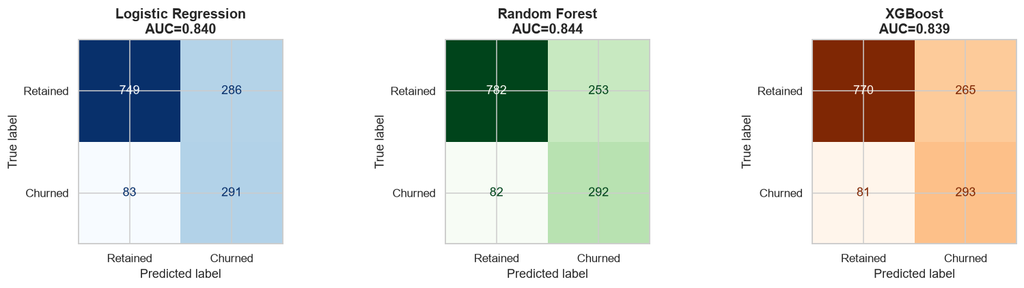

```
Saved: model_confusion_matrices.png
```

```python
fig, axes = plt.subplots(1, 3, figsize=(15, 4))
cmaps = ['Blues','Greens','Oranges']
for ax, (name, pred), cmap in zip(axes, preds.items(), cmaps):
    ConfusionMatrixDisplay.from_predictions(
        y_test, pred, display_labels=['Retained','Churned'],
        colorbar=False, ax=ax, cmap=cmap)
    auc = roc_auc_score(y_test, probas[name])
    ax.set_title(f'{name}\nAUC={auc:.3f}', fontweight='bold')
plt.tight_layout()
plt.savefig('model_confusion_matrices.png', bbox_inches='tight')
plt.show()
print('Saved: model_confusion_matrices.png')
```

### 5.5 ROC and Precision-Recall Curves

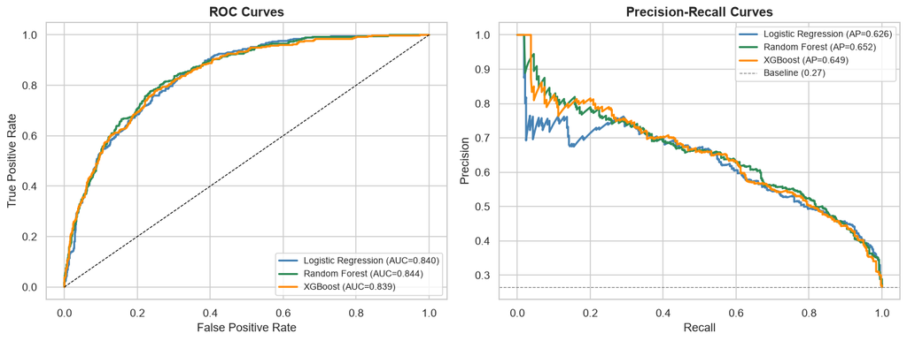

```
Saved: model_roc_pr.png
```

```python
fig, axes = plt.subplots(1, 2, figsize=(13, 5))
colors = ['steelblue','seagreen','darkorange']

for (name, proba), col in zip(probas.items(), colors):
    # ROC
    fpr, tpr, _ = roc_curve(y_test, proba)
    auc = roc_auc_score(y_test, proba)
    axes[0].plot(fpr, tpr, lw=2, color=col, label=f'{name} (AUC={auc:.3f})')
    # Precision-Recall
    prec, rec, _ = precision_recall_curve(y_test, proba)
    ap = average_precision_score(y_test, proba)
    axes[1].plot(rec, prec, lw=2, color=col, label=f'{name} (AP={ap:.3f})')

axes[0].plot([0,1],[0,1],'k--',lw=0.8)
axes[0].set_title('ROC Curves', fontweight='bold')
axes[0].set_xlabel('False Positive Rate'); axes[0].set_ylabel('True Positive Rate')
axes[0].legend(fontsize=9)

baseline = y_test.mean()
axes[1].axhline(baseline, ls='--', color='grey', lw=0.8, label=f'Baseline ({baseline:.2f})')
axes[1].set_title('Precision-Recall Curves', fontweight='bold')
axes[1].set_xlabel('Recall'); axes[1].set_ylabel('Precision')
axes[1].legend(fontsize=9)

plt.tight_layout()
plt.savefig('model_roc_pr.png', bbox_inches='tight')
plt.show()
print('Saved: model_roc_pr.png')
```

## 6. Threshold Optimisation

The default 0.5 threshold is rarely optimal for imbalanced problems. For churn, **recall matters more than precision** — missing a churner costs more than a false alarm. We sweep thresholds and find the one that maximises F2-score (weights recall twice as much as precision), then report the business tradeoff.

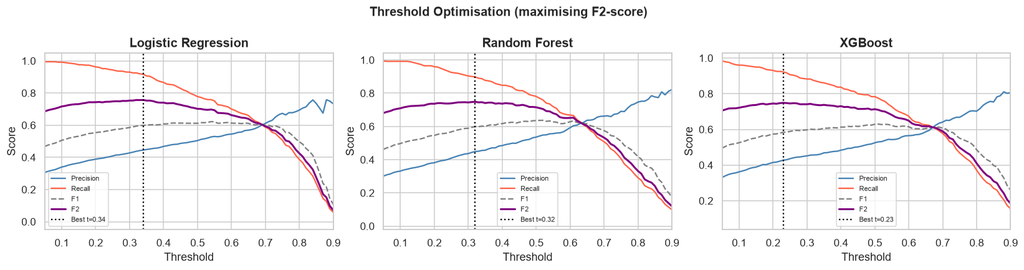

```
Saved: threshold_sweep.png

Optimal thresholds (F2-maximising):
  Logistic Regression    threshold = 0.34
  Random Forest          threshold = 0.32
  XGBoost                threshold = 0.23
```

```python
from sklearn.metrics import fbeta_score

def find_best_threshold(y_true, y_proba, beta=2, step=0.01):
    """Return threshold that maximises F-beta score."""
    thresholds = np.arange(0.05, 0.95, step)
    scores = [fbeta_score(y_true, (y_proba >= t).astype(int),
                          beta=beta, zero_division=0)
              for t in thresholds]
    best_idx = int(np.argmax(scores))
    return thresholds[best_idx], scores

fig, axes = plt.subplots(1, 3, figsize=(15, 4))
colors = ['steelblue','seagreen','darkorange']
best_thresholds = {}

for ax, (name, proba), col in zip(axes, probas.items(), colors):
    thresholds = np.arange(0.05, 0.95, 0.01)
    precisions, recalls, f1s, f2s = [], [], [], []
    for t in thresholds:
        pred_t = (proba >= t).astype(int)
        from sklearn.metrics import precision_score, recall_score, f1_score
        precisions.append(precision_score(y_test, pred_t, zero_division=0))
        recalls.append(recall_score(y_test, pred_t, zero_division=0))
        f1s.append(f1_score(y_test, pred_t, zero_division=0))
        f2s.append(fbeta_score(y_test, pred_t, beta=2, zero_division=0))

    best_t = thresholds[int(np.argmax(f2s))]
    best_thresholds[name] = best_t

    ax.plot(thresholds, precisions, label='Precision', color='steelblue', lw=1.5)
    ax.plot(thresholds, recalls,    label='Recall',    color='tomato',    lw=1.5)
    ax.plot(thresholds, f1s,        label='F1',        color='grey',      lw=1.5, ls='--')
    ax.plot(thresholds, f2s,        label='F2',        color='purple',    lw=2)
    ax.axvline(best_t, ls=':', color='black', lw=1.5, label=f'Best t={best_t:.2f}')
    ax.set_title(f'{name}', fontweight='bold')
    ax.set_xlabel('Threshold'); ax.set_ylabel('Score')
    ax.legend(fontsize=7.5); ax.set_xlim(0.05, 0.90)

plt.suptitle('Threshold Optimisation (maximising F2-score)', fontsize=13, fontweight='bold')
plt.tight_layout()
plt.savefig('threshold_sweep.png', bbox_inches='tight')
plt.show()
print('Saved: threshold_sweep.png')
print('\nOptimal thresholds (F2-maximising):')
for name, t in best_thresholds.items():
    print(f'  {name:<22} threshold = {t:.2f}')
```

```python
print('=== Performance at Optimal Thresholds ===\n')
for name in models:
    t = best_thresholds[name]
    pred_opt = (probas[name] >= t).astype(int)
    print(f'--- {name} (threshold={t:.2f}) ---')
    print(classification_report(y_test, pred_opt,
                                target_names=['Retained','Churned']))
    print()
```

```
=== Performance at Optimal Thresholds ===

--- Logistic Regression (threshold=0.34) ---
              precision    recall  f1-score   support

    Retained       0.95      0.59      0.73      1035
     Churned       0.45      0.92      0.60       374

    accuracy                           0.67      1409
   macro avg       0.70      0.75      0.66      1409
weighted avg       0.82      0.67      0.69      1409


--- Random Forest (threshold=0.32) ---
              precision    recall  f1-score   support

    Retained       0.94      0.60      0.73      1035
     Churned       0.45      0.90      0.60       374

    accuracy                           0.68      1409
   macro avg       0.70      0.75      0.67      1409
weighted avg       0.81      0.68      0.70      1409


--- XGBoost (threshold=0.23) ---
              precision    recall  f1-score   support

    Retained       0.95      0.55      0.70      1035
     Churned       0.43      0.92      0.58       374

    accuracy                           0.65      1409
   macro avg       0.69      0.74      0.64      1409
weighted avg       0.81      0.65      0.67      1409
```

## 7. SHAP Explainability

SHAP (SHapley Additive exPlanations) gives **model-agnostic, consistent feature attributions**. Unlike Gini importance (biased toward high-cardinality features) or LR coefficients (affected by multicollinearity), SHAP values tell us exactly how much each feature contributed to a specific prediction.

- **Global summary plot** — feature importance + direction
- **Waterfall plot** — explanation for the single highest-risk customer

### 7.1 XGBoost — Global SHAP Summary

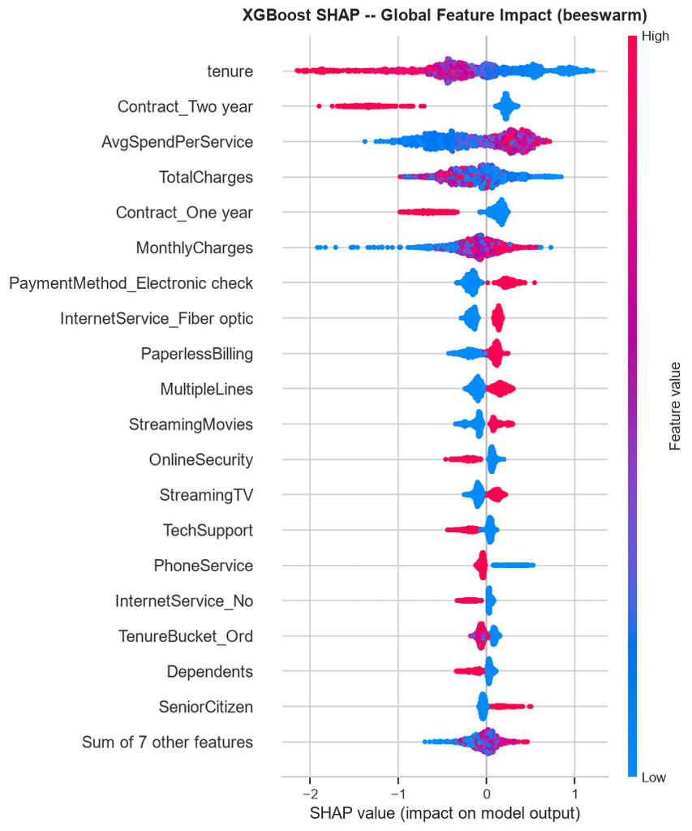

```
Saved: shap_xgb_beeswarm.png
```

```python
import shap
shap.initjs()

# TreeExplainer is exact and fast for tree-based models
explainer_xgb = shap.TreeExplainer(models['XGBoost'])
shap_values_xgb = explainer_xgb(X_test)

fig, ax = plt.subplots(figsize=(9, 7))
shap.plots.beeswarm(shap_values_xgb, max_display=20,
                    show=False)
plt.title('XGBoost SHAP -- Global Feature Impact (beeswarm)', fontweight='bold', pad=12)
plt.tight_layout()
plt.savefig('shap_xgb_beeswarm.png', bbox_inches='tight')
plt.show()
print('Saved: shap_xgb_beeswarm.png')
```

### 7.2 XGBoost — Mean |SHAP| Bar Chart

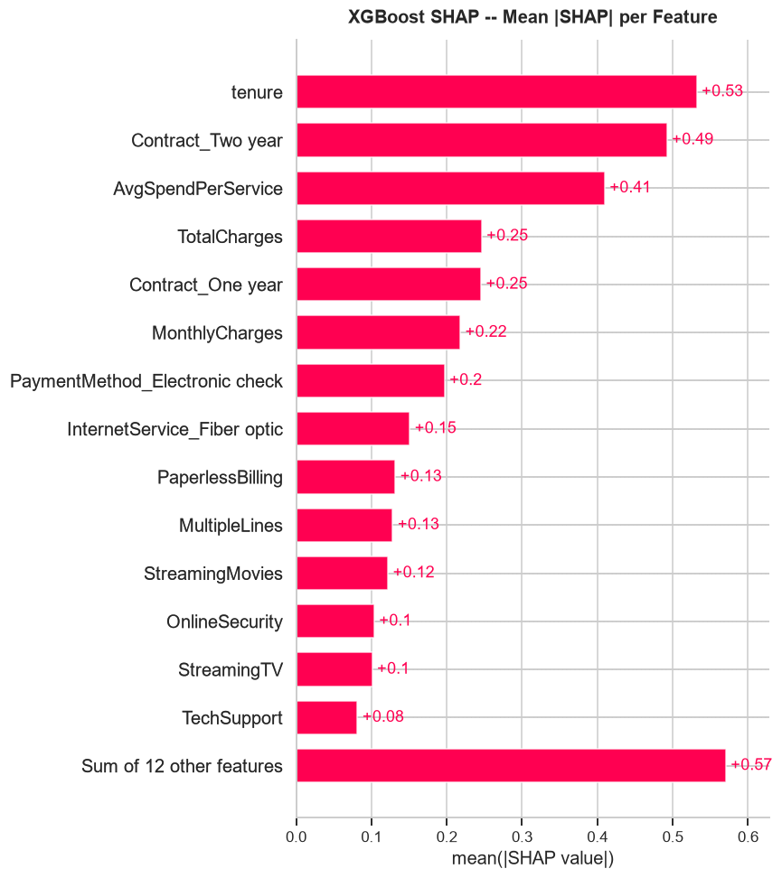

```
Saved: shap_xgb_bar.png
```

```python
fig, ax = plt.subplots(figsize=(8, 6))
shap.plots.bar(shap_values_xgb, max_display=15, show=False)
plt.title('XGBoost SHAP -- Mean |SHAP| per Feature', fontweight='bold', pad=12)
plt.tight_layout()
plt.savefig('shap_xgb_bar.png', bbox_inches='tight')
plt.show()
print('Saved: shap_xgb_bar.png')
```

### 7.3 XGBoost — Waterfall Plot for Highest-Risk Customer

```
Highest-risk customer index: 1175
Predicted churn probability: 0.976
Actual outcome: Churned

Customer profile:
                                          2631
SeniorCitizen                           1.0000
Partner                                 1.0000
Dependents                              0.0000
tenure                                  7.0000
PhoneService                            1.0000
MultipleLines                           1.0000
OnlineSecurity                          0.0000
OnlineBackup                            0.0000
DeviceProtection                        1.0000
TechSupport                             0.0000
StreamingTV                             1.0000
StreamingMovies                         1.0000
PaperlessBilling                        1.0000
MonthlyCharges                         99.2500
TotalCharges                          665.4500
TotalServicesCount                      6.0000
AvgSpendPerService                     14.1786
TenureBucket_Ord                        0.0000
gender_Male                             1.0000
InternetService_Fiber optic             1.0000
InternetService_No                      0.0000
Contract_One year                       0.0000
Contract_Two year                       0.0000
PaymentMethod_Credit card (automatic)   0.0000
PaymentMethod_Electronic check          1.0000
PaymentMethod_Mailed check              0.0000
```

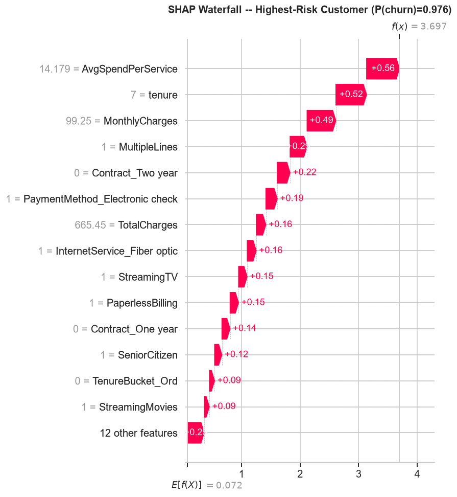

```
Saved: shap_xgb_waterfall.png
```

```python
# Find the customer with highest predicted churn probability
highest_risk_idx = int(np.argmax(probas['XGBoost']))
churn_prob = probas['XGBoost'][highest_risk_idx]
actual = y_test.iloc[highest_risk_idx]

print(f'Highest-risk customer index: {highest_risk_idx}')
print(f'Predicted churn probability: {churn_prob:.3f}')
print(f'Actual outcome: {"Churned" if actual==1 else "Retained"}')
print()
print('Customer profile:')
print(X_test.iloc[[highest_risk_idx]].T.to_string())

fig, ax = plt.subplots(figsize=(9, 7))
shap.plots.waterfall(shap_values_xgb[highest_risk_idx], max_display=15, show=False)
plt.title(f'SHAP Waterfall -- Highest-Risk Customer (P(churn)={churn_prob:.3f})',
          fontweight='bold', pad=12)
plt.tight_layout()
plt.savefig('shap_xgb_waterfall.png', bbox_inches='tight')
plt.show()
print('Saved: shap_xgb_waterfall.png')
```

### 7.4 Random Forest — SHAP Summary

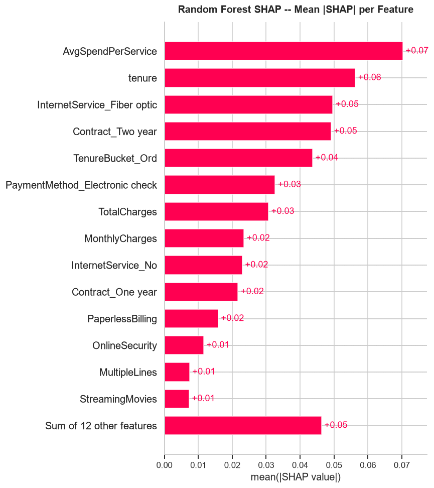

```
Saved: shap_rf_bar.png
```

```python
explainer_rf = shap.TreeExplainer(models['Random Forest'])
shap_values_rf = explainer_rf(X_test)

# For RF binary classifiers shap returns shape (n, features, 2) -- take class 1
if len(shap_values_rf.values.shape) == 3:
    sv_rf_class1 = shap.Explanation(
        values      = shap_values_rf.values[:,:,1],
        base_values = shap_values_rf.base_values[:,1],
        data        = shap_values_rf.data,
        feature_names = FEATURE_NAMES)
else:
    sv_rf_class1 = shap_values_rf

fig, ax = plt.subplots(figsize=(8, 6))
shap.plots.bar(sv_rf_class1, max_display=15, show=False)
plt.title('Random Forest SHAP -- Mean |SHAP| per Feature', fontweight='bold', pad=12)
plt.tight_layout()
plt.savefig('shap_rf_bar.png', bbox_inches='tight')
plt.show()
print('Saved: shap_rf_bar.png')
```

## 8. Model Comparison Table

All metrics computed on the held-out test set (20% of data, stratified). 'Opt. threshold' results use the F2-maximising threshold from Section 6.

```python
from sklearn.metrics import (
    precision_score, recall_score, f1_score, fbeta_score, accuracy_score
)

rows = []
for name in models:
    proba = probas[name]
    # Default threshold (0.5)
    pred_def = preds[name]
    # Optimal threshold
    t_opt = best_thresholds[name]
    pred_opt = (proba >= t_opt).astype(int)
    # CV AUC
    cv_auc_mean = cv_results[name]['test_roc_auc'].mean()
    cv_auc_std  = cv_results[name]['test_roc_auc'].std()

    for label, pred in [('Default (t=0.50)', pred_def),
                         (f'Optimal (t={t_opt:.2f})', pred_opt)]:
        rows.append({
            'Model':      name,
            'Threshold':  label,
            'CV AUC':     f'{cv_auc_mean:.3f} +/- {cv_auc_std:.3f}',
            'Test AUC':   round(roc_auc_score(y_test, proba), 3),
            'Accuracy':   round(accuracy_score(y_test, pred), 3),
            'Precision':  round(precision_score(y_test, pred, zero_division=0), 3),
            'Recall':     round(recall_score(y_test, pred, zero_division=0), 3),
            'F1':         round(f1_score(y_test, pred, zero_division=0), 3),
            'F2':         round(fbeta_score(y_test, pred, beta=2, zero_division=0), 3),
        })

comparison_df = pd.DataFrame(rows)
print(comparison_df.to_string(index=False))
comparison_df
```

```
              Model        Threshold          CV AUC  Test AUC  Accuracy  Precision  Recall     F1     F2
Logistic Regression Default (t=0.50) 0.845 +/- 0.012    0.8400    0.7380     0.5040  0.7780 0.6120 0.7020
Logistic Regression Optimal (t=0.34) 0.845 +/- 0.012    0.8400    0.6750     0.4450  0.9170 0.6000 0.7570
      Random Forest Default (t=0.50) 0.845 +/- 0.012    0.8440    0.7620     0.5360  0.7810 0.6350 0.7150
      Random Forest Optimal (t=0.32) 0.845 +/- 0.012    0.8440    0.6810     0.4490  0.8980 0.5990 0.7490
            XGBoost Default (t=0.50) 0.839 +/- 0.012    0.8390    0.7540     0.5250  0.7830 0.6290 0.7130
            XGBoost Optimal (t=0.23) 0.839 +/- 0.012    0.8390    0.6520     0.4280  0.9220 0.5840 0.7490
```

|  | Model | Threshold | CV AUC | Test AUC | Accuracy | Precision | Recall | F1 | F2 |
| --- | --- | --- | --- | --- | --- | --- | --- | --- | --- |
| 0 | Logistic Regression | Default (t=0.50) | 0.845 +/- 0.012 | 0.8400 | 0.7380 | 0.5040 | 0.7780 | 0.6120 | 0.7020 |
| 1 | Logistic Regression | Optimal (t=0.34) | 0.845 +/- 0.012 | 0.8400 | 0.6750 | 0.4450 | 0.9170 | 0.6000 | 0.7570 |
| 2 | Random Forest | Default (t=0.50) | 0.845 +/- 0.012 | 0.8440 | 0.7620 | 0.5360 | 0.7810 | 0.6350 | 0.7150 |
| 3 | Random Forest | Optimal (t=0.32) | 0.845 +/- 0.012 | 0.8440 | 0.6810 | 0.4490 | 0.8980 | 0.5990 | 0.7490 |
| 4 | XGBoost | Default (t=0.50) | 0.839 +/- 0.012 | 0.8390 | 0.7540 | 0.5250 | 0.7830 | 0.6290 | 0.7130 |
| 5 | XGBoost | Optimal (t=0.23) | 0.839 +/- 0.012 | 0.8390 | 0.6520 | 0.4280 | 0.9220 | 0.5840 | 0.7490 |

### 8.1 Feature Importance: LR Coefficients vs RF vs XGBoost SHAP

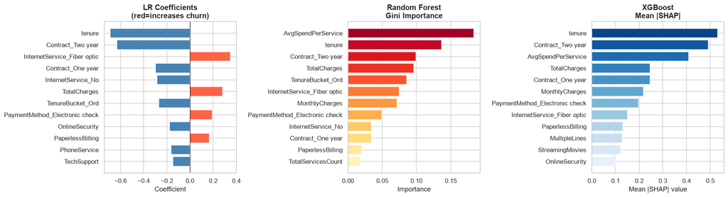

```
Saved: feature_importance_comparison.png

Consensus top features (appear in top-5 of >=2 models):
  - Contract_Two year
  - Contract_One year
  - tenure
  - TotalCharges
  - AvgSpendPerService
```

```python
lr_coefs = pd.Series(
    lr_pipe.named_steps['clf'].coef_[0], index=FEATURE_NAMES
).sort_values(key=abs, ascending=False)

rf_imp = pd.Series(models['Random Forest'].feature_importances_,
                   index=FEATURE_NAMES).sort_values(ascending=False)

xgb_shap_mean = pd.Series(
    np.abs(shap_values_xgb.values).mean(axis=0),
    index=FEATURE_NAMES).sort_values(ascending=False)

top_n = 12
fig, axes = plt.subplots(1, 3, figsize=(18, 5))

# LR coefficients
c = lr_coefs.head(top_n)
colors_lr = ['tomato' if v > 0 else 'steelblue' for v in c.values]
axes[0].barh(c.index[::-1], c.values[::-1], color=colors_lr[::-1])
axes[0].axvline(0, color='black', lw=0.8)
axes[0].set_title('LR Coefficients\n(red=increases churn)', fontweight='bold')
axes[0].set_xlabel('Coefficient')

# RF importance
rf_top = rf_imp.head(top_n)
axes[1].barh(rf_top.index[::-1], rf_top.values[::-1],
             color=sns.color_palette('YlOrRd_r', top_n)[::-1])
axes[1].set_title('Random Forest\nGini Importance', fontweight='bold')
axes[1].set_xlabel('Importance')

# XGBoost SHAP
xgb_top = xgb_shap_mean.head(top_n)
axes[2].barh(xgb_top.index[::-1], xgb_top.values[::-1],
             color=sns.color_palette('Blues_r', top_n)[::-1])
axes[2].set_title('XGBoost\nMean |SHAP|', fontweight='bold')
axes[2].set_xlabel('Mean |SHAP| value')

plt.tight_layout()
plt.savefig('feature_importance_comparison.png', bbox_inches='tight')
plt.show()
print('Saved: feature_importance_comparison.png')

# Consensus top features
top5_lr   = set(lr_coefs.head(5).index)
top5_rf   = set(rf_imp.head(5).index)
top5_shap = set(xgb_shap_mean.head(5).index)
consensus = top5_lr & top5_rf | top5_lr & top5_shap | top5_rf & top5_shap
print(f'\nConsensus top features (appear in top-5 of >=2 models):')
for f in consensus:
    print(f'  - {f}')
```

## 9. QC Checks

Seven automated checks before trusting any model output.

```python
qc = []

# 1. Duplicate IDs
n_dup = df_raw['customerID'].duplicated().sum()
qc.append({'Check': 'Duplicate customerIDs',
           'Result': str(n_dup),
           'Status': 'PASS' if n_dup == 0 else 'FAIL'})

# 2. Train/test churn rate drift
drift = abs(y_train.mean() - y_test.mean())
qc.append({'Check': 'Train/test churn rate drift',
           'Result': f'{drift:.5f}',
           'Status': 'PASS' if drift < 0.01 else 'FAIL'})

# 3. Data leakage
leaky = [c for c in X.columns if 'churn' in c.lower() or 'target' in c.lower()]
qc.append({'Check': 'Data leakage scan',
           'Result': str(leaky) if leaky else 'None found',
           'Status': 'FAIL' if leaky else 'PASS'})

# 4. TotalCharges dtype
tc_ok = str(df['TotalCharges'].dtype).startswith('float')
qc.append({'Check': 'TotalCharges dtype',
           'Result': str(df['TotalCharges'].dtype),
           'Status': 'PASS' if tc_ok else 'FAIL'})

# 5. Nulls in feature matrix
nulls = int(X.isnull().sum().sum())
qc.append({'Check': 'Nulls in feature matrix',
           'Result': str(nulls),
           'Status': 'PASS' if nulls == 0 else 'FAIL'})

# 6. Near-zero-variance features
from sklearn.feature_selection import VarianceThreshold
vt = VarianceThreshold(threshold=0.01)
vt.fit(X_train)
low_var = [f for f, s in zip(FEATURE_NAMES, vt.variances_) if s < 0.01]
qc.append({'Check': 'Near-zero-variance features',
           'Result': str(low_var) if low_var else 'None',
           'Status': 'WARN' if low_var else 'PASS'})

# 7. Multicollinearity flag
tc_corr = abs(df[['tenure','MonthlyCharges','TotalCharges']]
              .corr().loc['TotalCharges','tenure'])
qc.append({'Check': 'TotalCharges ~ tenure correlation',
           'Result': f'r={tc_corr:.3f}',
           'Status': 'WARN -- LR coefs affected' if tc_corr > 0.8 else 'PASS'})

qc_df = pd.DataFrame(qc)
print(qc_df.to_string(index=False))
```

```
                            Check     Result                    Status
            Duplicate customerIDs          0                      PASS
      Train/test churn rate drift    0.00008                      PASS
                Data leakage scan None found                      PASS
               TotalCharges dtype    float64                      PASS
          Nulls in feature matrix          0                      PASS
      Near-zero-variance features       None                      PASS
TotalCharges ~ tenure correlation    r=0.826 WARN -- LR coefs affected
```

## 10. Business Insights & Revenue Impact

Translating model outputs into actions and estimated financial impact.

### 10.1 Revenue at Risk

```python
total_customers = len(df)
churn_rate      = df['Churn_Flag'].mean()
avg_monthly     = df['MonthlyCharges'].mean()
churned_n       = int(total_customers * churn_rate)
annual_at_risk  = churned_n * avg_monthly * 12

print('=== Annual Revenue at Risk ===')
print(f'  Total customers        : {total_customers:,}')
print(f'  Churn rate             : {churn_rate:.1%}')
print(f'  Customers churning/yr  : ~{churned_n:,}')
print(f'  Avg monthly charge     : ${avg_monthly:.2f}')
print(f'  Annual revenue at risk : ${annual_at_risk:,.0f}')
```

```
=== Annual Revenue at Risk ===
  Total customers        : 7,043
  Churn rate             : 26.5%
  Customers churning/yr  : ~1,869
  Avg monthly charge     : $64.76
  Annual revenue at risk : $1,452,475
```

### 10.2 Model-Driven Retention ROI

```python
# Best model = XGBoost (highest AUC)
best_model_name = max(models, key=lambda n: roc_auc_score(y_test, probas[n]))
best_proba = probas[best_model_name]
best_t = best_thresholds[best_model_name]

# Simulate scoring all customers
all_probas = models[best_model_name].predict_proba(X)[:,1]
flagged_mask = all_probas >= best_t
n_flagged = flagged_mask.sum()

# Business assumptions (conservative)
retention_offer_cost = 50      # $ per customer contacted
success_rate         = 0.30    # 30% of flagged churners saved
avg_monthly_revenue  = avg_monthly
avg_customer_lifetime_months = 24

true_churners_flagged = (all_probas[flagged_mask] >= best_t).sum()  # all flagged
# Estimate true positives using model recall on full set
actual_churners = int(y.sum())
test_recall = recall_score(y_test, (best_proba >= best_t).astype(int))
est_true_pos = int(actual_churners * test_recall)

revenue_saved  = est_true_pos * success_rate * avg_monthly_revenue * avg_customer_lifetime_months
campaign_cost  = n_flagged * retention_offer_cost
net_roi        = revenue_saved - campaign_cost

print(f'=== Model-Driven Retention Campaign ROI ===')
print(f'  Best model             : {best_model_name}')
print(f'  Optimal threshold      : {best_t:.2f}')
print(f'  Customers flagged      : {n_flagged:,} ({n_flagged/len(y)*100:.1f}% of base)')
print(f'  Estimated true churners caught (recall={test_recall:.0%}): {est_true_pos:,}')
print()
print(f'  Assumptions:')
print(f'    Retention offer cost : ${retention_offer_cost}/customer contacted')
print(f'    Retention success    : {success_rate:.0%} of caught churners saved')
print(f'    Avg customer LTV     : {avg_customer_lifetime_months} months x ${avg_monthly_revenue:.2f}/mo')
print()
print(f'  Revenue saved          : ${revenue_saved:,.0f}')
print(f'  Campaign cost          : ${campaign_cost:,.0f}')
print(f'  Net ROI                : ${net_roi:,.0f}')
print(f'  ROI ratio              : {revenue_saved/max(campaign_cost,1):.1f}x')
```

```
=== Model-Driven Retention Campaign ROI ===
  Best model             : Random Forest
  Optimal threshold      : 0.32
  Customers flagged      : 3,725 (52.9% of base)
  Estimated true churners caught (recall=90%): 1,679

  Assumptions:
    Retention offer cost : $50/customer contacted
    Retention success    : 30% of caught churners saved
    Avg customer LTV     : 24 months x $64.76/mo

  Revenue saved          : $782,891
  Campaign cost          : $186,250
  Net ROI                : $596,641
  ROI ratio              : 4.2x
```

### 10.3 Top 10 Highest-Risk Customers (Retention Priority List)

```python
# Attach predictions back to original df
df_scored = df.copy()
df_scored['ChurnProbability'] = models[best_model_name].predict_proba(X)[:,1]
df_scored['RiskTier'] = pd.cut(df_scored['ChurnProbability'],
    bins=[0, 0.3, 0.6, 1.0],
    labels=['Low Risk', 'Medium Risk', 'High Risk'])

display_cols = ['customerID','Contract','tenure','MonthlyCharges',
                'InternetService','TechSupport','PaymentMethod',
                'ChurnProbability','RiskTier']

top10 = (df_scored[df_scored['Churn']=='No']   # only retained customers
            .sort_values('ChurnProbability', ascending=False)
            .head(10)[display_cols]
            .reset_index(drop=True))

top10['ChurnProbability'] = top10['ChurnProbability'].round(3)
print('Top 10 currently-retained customers most likely to churn next:')
print(top10.to_string(index=False))
top10
```

```
Top 10 currently-retained customers most likely to churn next:
customerID       Contract  tenure  MonthlyCharges InternetService TechSupport    PaymentMethod  ChurnProbability  RiskTier
5542-TBBWB Month-to-month       1         69.9000     Fiber optic          No Electronic check            0.9440 High Risk
4912-PIGUY Month-to-month       1         84.6000     Fiber optic          No Electronic check            0.9340 High Risk
1452-VOQCH Month-to-month       1         75.1000     Fiber optic          No Electronic check            0.9320 High Risk
5150-ITWWB Month-to-month       3         94.8500     Fiber optic          No Electronic check            0.9290 High Risk
8161-QYMTT Month-to-month       7         94.1000     Fiber optic          No Electronic check            0.9220 High Risk
7439-DKZTW Month-to-month       1         80.5500     Fiber optic          No Electronic check            0.9220 High Risk
1628-BIZYP Month-to-month       1         85.0000     Fiber optic          No Electronic check            0.9190 High Risk
0021-IKXGC Month-to-month       1         72.1000     Fiber optic          No Electronic check            0.9170 High Risk
4927-WWOOZ Month-to-month       2         91.4500     Fiber optic          No Electronic check            0.9160 High Risk
7577-SWIFR Month-to-month       1         89.2500     Fiber optic          No Electronic check            0.9120 High Risk
```

|  | customerID | Contract | tenure | MonthlyCharges | InternetService | TechSupport | PaymentMethod | ChurnProbability | RiskTier |
| --- | --- | --- | --- | --- | --- | --- | --- | --- | --- |
| 0 | 5542-TBBWB | Month-to-month | 1 | 69.9000 | Fiber optic | No | Electronic check | 0.9440 | High Risk |
| 1 | 4912-PIGUY | Month-to-month | 1 | 84.6000 | Fiber optic | No | Electronic check | 0.9340 | High Risk |
| 2 | 1452-VOQCH | Month-to-month | 1 | 75.1000 | Fiber optic | No | Electronic check | 0.9320 | High Risk |
| 3 | 5150-ITWWB | Month-to-month | 3 | 94.8500 | Fiber optic | No | Electronic check | 0.9290 | High Risk |
| 4 | 8161-QYMTT | Month-to-month | 7 | 94.1000 | Fiber optic | No | Electronic check | 0.9220 | High Risk |
| 5 | 7439-DKZTW | Month-to-month | 1 | 80.5500 | Fiber optic | No | Electronic check | 0.9220 | High Risk |
| 6 | 1628-BIZYP | Month-to-month | 1 | 85.0000 | Fiber optic | No | Electronic check | 0.9190 | High Risk |
| 7 | 0021-IKXGC | Month-to-month | 1 | 72.1000 | Fiber optic | No | Electronic check | 0.9170 | High Risk |
| 8 | 4927-WWOOZ | Month-to-month | 2 | 91.4500 | Fiber optic | No | Electronic check | 0.9160 | High Risk |
| 9 | 7577-SWIFR | Month-to-month | 1 | 89.2500 | Fiber optic | No | Electronic check | 0.9120 | High Risk |